# Part 2

Claire Madden

11/27/2018

**Table X: Female PhD Recipients by Field (1985, 2000, 2015)** Number of doctoral degrees awarded to women in the fields of Physical and Earth Sciences, Engineering, Education, and Humanities and Arts in the years 1985, 2000, and 2015.

| Year | Physical and Earth Sciences | Engineering | Education | Humanities and Arts |
| --- | --- | --- | --- | --- |
| 1985 | 569 | 198 | 3491 | 1392 |
| 2000 | 1022 | 838 | 4179 | 2672 |
| 2015 | 1988 | 2301 | 3502 | 2832 |

**Table X: Proportions of Degrees Awarded by Year** The percentage of doctoral degrees awarded among the four subjects of Physical and Earth Sciences, Engineering, Education, and Humanities and Arts. Proportion of recipients in each field varied significantly by year [($\chi^2$(8) = 2360, p < 0.001.]

| Year | Physical and Earth Sciences | Engineering | Education | Humanities and Arts |
| --- | --- | --- | --- | --- |
| 1985 | 10.1% | 3.5% | 61.8% | 24.6% |
| 2000 | 11.7% | 9.6% | 48.0% | 30.7% |
| 2015 | 18.7% | 21.7% | 33.0% | 26.7% |

The ratio of doctoral degrees awarded to women changed significantly between 1985 and 2015 [$\chi^2$ (8) = 2360, p < .001]. Figure X shows the proportion of degrees awarded in the fields of Education, Physical and Earth Sciences, Engineering, and Education in 1985, 2000, and 2015. In 1985, a large majority of PhDs were awarded to women in Education (61.8%) and Humanities and Arts (24.6%), while only 13.6% were awarded to women in the fields of Engineering or Physical and Earth Science. By 2015, the ratio was much more balanced, as can be seen in Figure X. The largest share of degrees was still awarded to women in Education (33.0%), but the smallest share, Physical and Earth Sciences, is now 18.7% of all degrees awarded in these four fields.

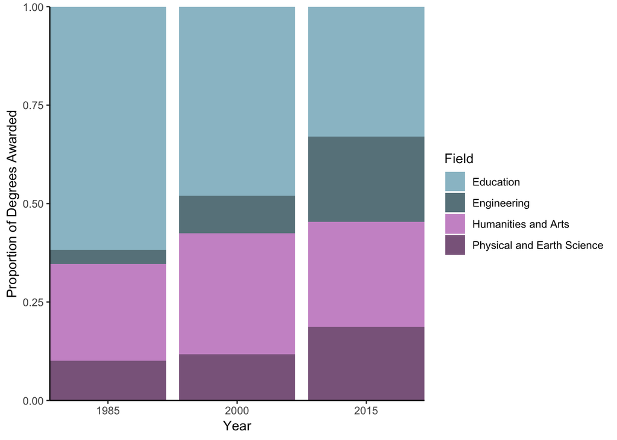

**Figure X: Female PhD Recipients by Field (1985, 2000, 2015)** Proportion of doctoral degrees awarded to women in the fields of Education, Engineering, Humanities and Arts, and Physical and Earth Science. See Table X for raw numbers of degrees awarded in each field every year, and Table X for exact proportions of degrees awarded to each field by year.